# PDX Bike Count Analysis

by Kevin Saavedra

This document summarizes the work that was completed during the Introduction to Scientific Computing for Planners, Engineers, and Scientists course offered by PSU in August 2018.

### Data Loading

We first needed to specify the packages that we would be working with.

```r
library(tidyverse)
library(readxl)
```

Next, we created a function that would load bike count data in Excel format. Note that the `date` column was mutated in order to simplify later joining with weather data.

```r
load_bridge <- function(bridge_name) {
  bridge_data <- read_excel(
    "../data/Hawthorne Tilikum Steel daily bike counts 073118.xlsx",
    sheet = bridge_name, skip = 1)
  bridge_data <- add_column(bridge_data, name = bridge_name) %>%
  mutate(date = as.Date(date, format = '%m/%d/%Y'))
  return(bridge_data)
}

bridges <- c("Hawthorne", "Tilikum", "Steel")
all_bridges <-  lapply(bridges, load_bridge)
Hawthorne <- all_bridges[[1]] %>%
  rename(westbound = `north side (westbound)`) %>%
  rename(eastbound = `south side (eastbound)`)

Tilikum <-  all_bridges[2]

Steel <- all_bridges[[3]] %>%
  select(-c(`River Walk (lower 2-way)`)) %>%
  rename(westbound = `north side (westbound)`) %>%
  rename(eastbound = `south side (eastbound)`)
```

Next, we needed to join bridge and weather data along the date columns.

```r
weather_data_csv <- read_csv("../data/NCDC-CDO-USC00356750.csv") %>%
  select(-c(STATION, NAME))

consolidated_bridge <- bind_rows(Hawthorne, Tilikum, Steel)

all_data <- left_join(consolidated_bridge, weather_data_csv, by = c("date" = "DATE"))
```

### Visualizing data with ggplot2

We were able to visualize data using the recommended ggplot package. We looked at total bicycle ridership counts plotted as a function of total precipitation for that day.

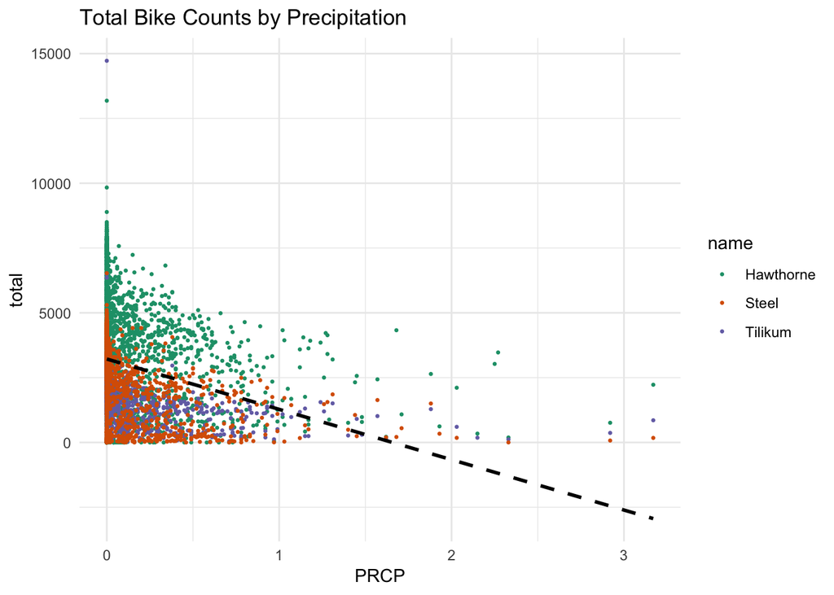

```r
all_data %>%
 ggplot(aes(x=PRCP, y=total, color=name)) +
 theme_minimal() +
 geom_point(size=.5) +
 stat_smooth(method=lm, se=FALSE, linetype="dashed", aes(group=1),
             size=1, color="black") +
 labs(title= "Total Bike Counts by Precipitation") +
 scale_color_brewer(palette="Dark2")
```

We may be used to rain, but not enough for most of us to ride our bikes in it!

### Visualizing the new Tilikum Bridge ridership with the neighboring Hawthorne Bridge.

How does the new bike-and-transit Tilikum Bridge square against the older Hawthorne Bridge? We took a look at that.

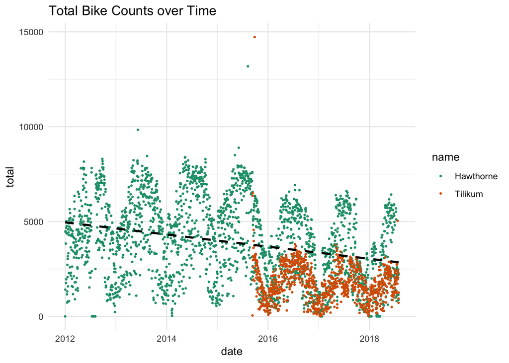

```r
tilikum_open <- all_data  %>%
  filter(name == 'Hawthorne' | name == 'Tilikum')

tilikum_open %>%  ggplot(aes(x=date, y=total, color=name)) +
  theme_minimal() +
  geom_point(size=.5) +
  stat_smooth(data=subset(all_data, name == "Hawthorne"), method=lm, se=FALSE, linetype="dashed", aes(group=1),
              size=1, color="black") +
  labs(title= "Total Bike Counts over Time") +
  scale_color_brewer(palette="Dark2")
```

There appears to be a noticeable decline in ridership on the Hawthorne Bridge after the Tilikum Bridge opened.

### Further investigating the effect of the Tilikum Bridge on the Hawthorne Bridge

We could take a more in-depth look at how the opening of the new Tilikum Bridge in 2015 affected ridership on the Hawthorne Bridge. We needed to approach the Hawthorne Bridge data as a time series.

We needed to load a new library that will work with this time series data.

```r
library(ggfortify)
```

Filtering out for Hawthorne Bridge data, we can then address seasonality.

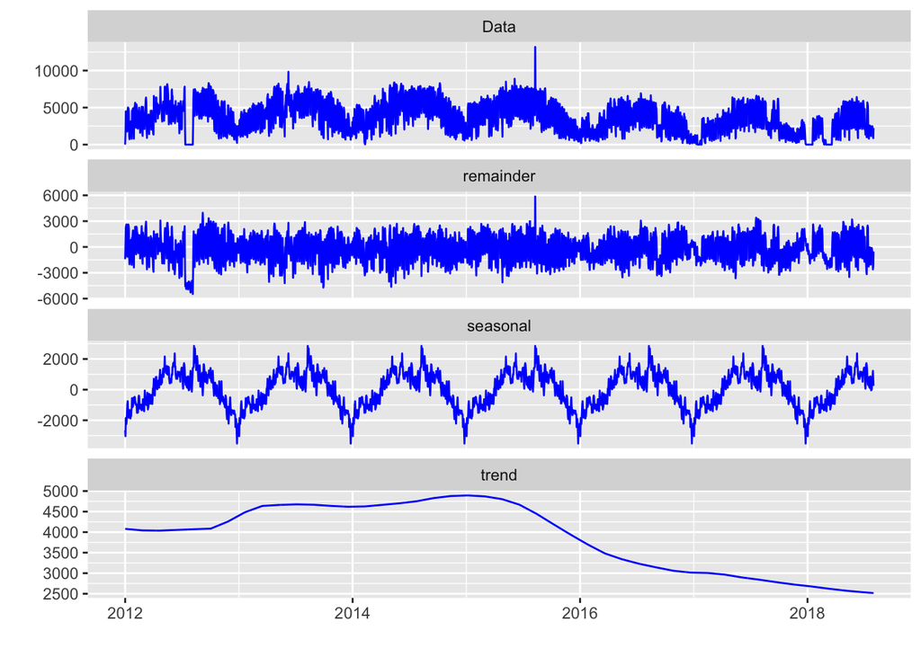

```r
Hawthorne_series <- all_data %>%
  filter(name == "Hawthorne") %>%
  select(date, total, name) %>%
  group_by(date)

hawthorne_ts <- ts(Hawthorne_series$total, start=2012, frequency=365)
autoplot(stl(hawthorne_ts, s.window = 'periodic'), ts.colour = 'blue')
```

When accounting for seasonality effects, it’s clear that the September 2015 opening of the Tilikum Bridge had an effect on reducing bike ridership on the Hawthorne Bridge.

### Applying linear regression models using a split-apply-combine approach

#### Or: The trouble with tibbles!

[figure not shown]

(No, not those.)

We learned how to nest tibbles within tibbles! Again, we have to load some new libraries first.

```r
library(purrr)
library(broom)
```

Then, apply a linear regression to all these datafiles.

```r
# Linear regression application function
tot_vs_weather <- function(df) {
  lm(total ~ TMIN + TMAX + PRCP, data = df) %>%
  summary()
}

# Nest the data
all_data_nested <- all_data %>%
    nest(-name)

# Apply the linear regression model
weather_model <- all_data_nested %>%
  mutate(fit = purrr::map(data, tot_vs_weather),
         tidy = purrr::map(fit, tidy)) %>%
  select(name, tidy) %>%
  unnest(tidy)
```

Note the `unnest(tidy)` to unpack the nested tibbles, so that it’s not tibbles all the way down.